# Analyze results from data from Mart

The goal of this analysis is to determine the cutting treatment I will apply in my experiment.

Task to do:

## Dataset preparation

```r
setwd("../thesis_chap2_alicante/")

data <- read.table(file="Mart_data.csv", sep=";" , dec=",", header=TRUE)

# We want those variables are considered as factor
factor <- c("terrace", "treatment", "watering", "rabbit", "plot", "microsite")
for (i in 1:length(factor)) {
    data[,factor[i]] <- as.factor(data[,factor[i]])
}
str(data)
```

```
## 'data.frame':    1284 obs. of  10 variables:
##  $ terrace        : Factor w/ 4 levels "1","2","3","4": 1 1 1 1 1 1 1 1 1 1 ...
##  $ treatment      : Factor w/ 4 levels "0","1","2","3": 2 2 2 2 2 2 2 2 2 2 ...
##  $ watering       : Factor w/ 2 levels "0","1": 2 2 1 2 1 1 2 2 1 1 ...
##  $ rabbit         : Factor w/ 2 levels "0","1": 1 2 2 2 2 2 2 2 2 2 ...
##  $ plot           : Factor w/ 16 levels "1","2","3","4",..: 1 1 1 1 1 1 1 1 1 1 ...
##  $ label          : Factor w/ 1261 levels "1","10","100",..: 1111 1122 1133 1143 1155 1166 1177 1188 1199 1210 ...
##  $ microsite      : Factor w/ 2 levels "0","1": 2 1 2 1 1 2 2 1 2 1 ...
##  $ lnheightoct14  : num  0 0 0 0 0 0 0 0 0 0 ...
##  $ lnheightmay2014: num  -1.705 -1.792 -1.322 -0.693 0.452 ...
##  $ survival       : int  0 0 0 0 0 0 0 0 0 0 ...
```

### Explicative variables

The height variables are defined in neperian logarithme because as we will see later, there are a lot of extrem values. This logarithme transformation permit to have normalized values and so, to respect hypothesis of the linear model.

### Exploratory variables

In the previous code, I defined them as factor. Finally, we have:

- `treatment`: grazing variable
  - 0: no grazing
  - 1: low grazing
  - 2: high grazing
  - 3: rabbit grazing
- `rabbit`: Were they grazed by rabbit?
  - 0: no
  - 1: yes
- `microsite`:
  - 0: open
  - 1: patch

## Data exploration

### Proportion of survival in each terrace and between microsites

```r
tapply(as.numeric(data$survival),
       INDEX=list(terrace=data$terrace,
          microsite=data$microsite),
       FUN=function(x){round(mean(x),2)})
```

```
##        microsite
## terrace    0    1
##       1 0.10 0.08
##       2 0.43 0.38
##       3 0.24 0.33
##       4 0.39 0.37
```

We want have the mean size reduction of Antillys because of grazing, so we keep only the Antyllis which were alive. Moreover, there was so much mortality in the first terrace that I exclude it from the analysis.

```r
data <- data[which(data$survival==1),]
data <- data[-which(data$terrace==1),]
```

## Data visualisation

### Are data normally distributed ?

It’s not too bad!

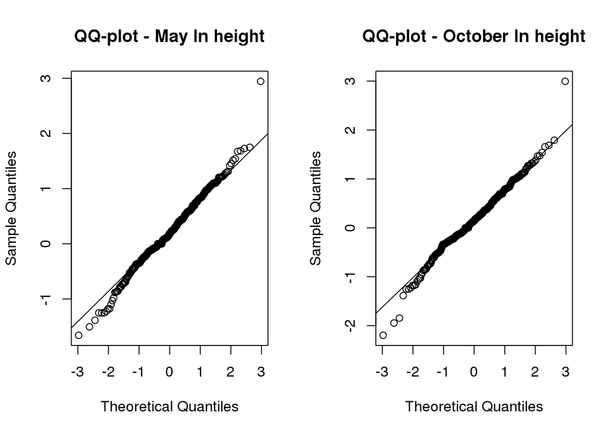

```r
# Data visualisation
# pdf(file="QQ_plot.pdf", paper="a4r")
par(mfrow=c(1,2))
qqnorm(data$lnheightmay2014, main = "QQ-plot - May ln height")
qqline(data$lnheightmay2014)
qqnorm(data$lnheightoct14, main = "QQ-plot - October ln height")
qqline(data$lnheightoct14)
```

```r
# dev.off()
par(mfrow=c(1,1))
```

### How are the data when we untransform them ?

We can see why Mart transformed his data. There are not normally distributed. An alternative hypothesis should be Mart didn’t transform the transform the exploratory variables by the neperian logarithme, but it’s not likely to be the case because of the names of the variables (contains “ln”).

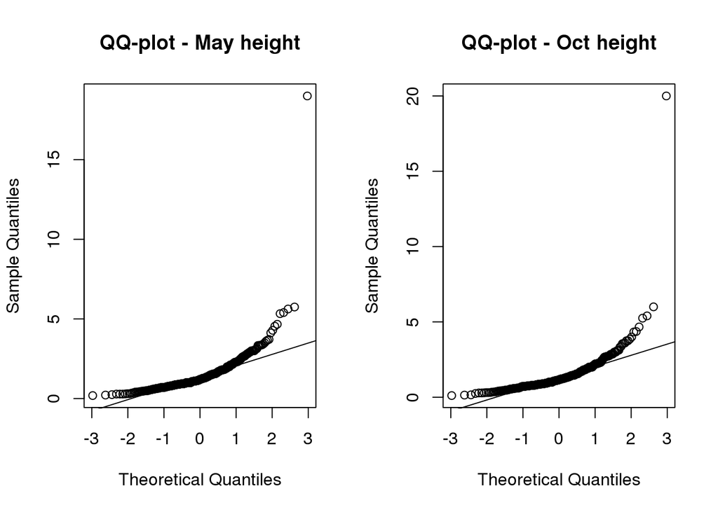

```r
data$may <- exp(data$lnheightmay2014)  #Data untransformation by exponential
data$oct <- exp(data$lnheightoct14)

par(mfrow=c(1,2))
qqnorm(data$may, main = "QQ-plot - May height");qqline(data$may)
qqnorm(data$oct, main = "QQ-plot - Oct height");qqline(data$oct)
```

```r
par(mfrow=c(1,1))
```

### Correlation between the variables

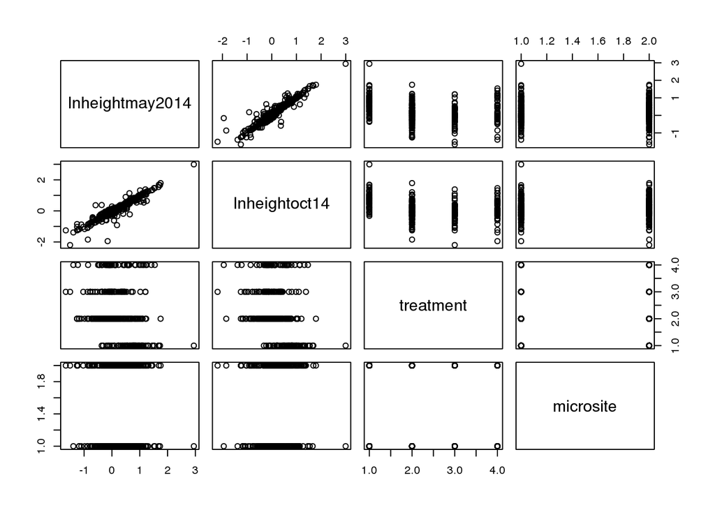

```r
plot(data[,c("lnheightmay2014","lnheightoct14", "treatment","microsite")])
```

## Statistical models

I proceed by ascendant analysis, i.e. I begin by the simplest model and I increase the complexity.

```r
## Dépenpence of size between the two dates
mod <- lm(lnheightoct14 ~ lnheightmay2014, data=data)
summary(mod)
```

```
##
## Call:
## lm(formula = lnheightoct14 ~ lnheightmay2014, data = data)
##
## Residuals:
##      Min       1Q   Median       3Q      Max
## -1.75087 -0.04115  0.03279  0.06323  0.98243
##
## Coefficients:
##                 Estimate Std. Error t value Pr(>|t|)
## (Intercept)     -0.04586    0.01184  -3.874 0.000129 ***
## lnheightmay2014  0.96777    0.01803  53.678  < 2e-16 ***
## ---
## Signif. codes:  0 '***' 0.001 '**' 0.01 '*' 0.05 '.' 0.1 ' ' 1
##
## Residual standard error: 0.2065 on 339 degrees of freedom
##   (2 observations deleted due to missingness)
## Multiple R-squared:  0.8947, Adjusted R-squared:  0.8944
## F-statistic:  2881 on 1 and 339 DF,  p-value: < 2.2e-16
```

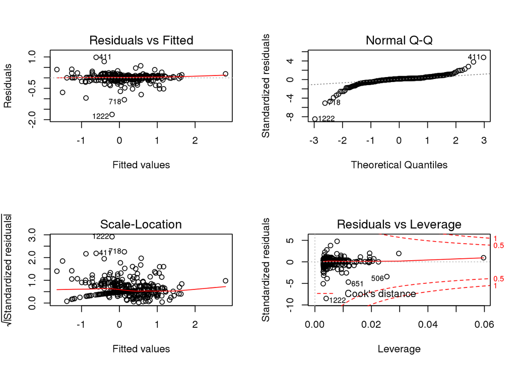

```r
par(mfrow=c(2,2))
plot(mod)
```

```r
par(mfrow=c(1,1))

mod <- lm(lnheightoct14 ~ lnheightmay2014 + microsite , data=data)
summary(mod)
```

```
##
## Call:
## lm(formula = lnheightoct14 ~ lnheightmay2014 + microsite, data = data)
##
## Residuals:
##      Min       1Q   Median       3Q      Max
## -1.74305 -0.04014  0.03389  0.06144  0.99026
##
## Coefficients:
##                 Estimate Std. Error t value Pr(>|t|)
## (Intercept)     -0.05368    0.01628  -3.297  0.00108 **
## lnheightmay2014  0.96779    0.01804  53.638  < 2e-16 ***
## microsite1       0.01566    0.02238   0.700  0.48448
## ---
## Signif. codes:  0 '***' 0.001 '**' 0.01 '*' 0.05 '.' 0.1 ' ' 1
##
## Residual standard error: 0.2067 on 338 degrees of freedom
##   (2 observations deleted due to missingness)
## Multiple R-squared:  0.8949, Adjusted R-squared:  0.8943
## F-statistic:  1439 on 2 and 338 DF,  p-value: < 2.2e-16
```

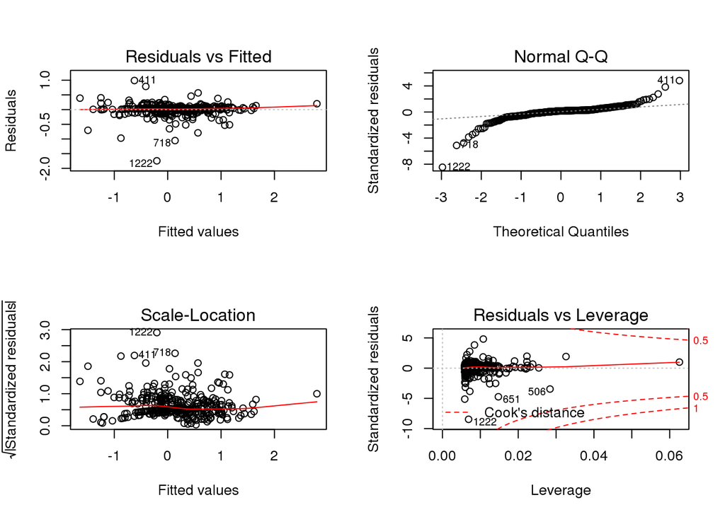

```r
par(mfrow=c(2,2))
plot(mod)
```

```r
par(mfrow=c(1,1))

mod <- lm(lnheightoct14 ~  lnheightmay2014 + treatment + microsite , data=data)
summary(mod)
```

```
##
## Call:
## lm(formula = lnheightoct14 ~ lnheightmay2014 + treatment + microsite,
##     data = data)
##
## Residuals:
##      Min       1Q   Median       3Q      Max
## -1.69535 -0.04558  0.02520  0.07031  0.97649
##
## Coefficients:
##                 Estimate Std. Error t value Pr(>|t|)
## (Intercept)     -0.01254    0.02907  -0.431   0.6665
## lnheightmay2014  0.95362    0.02028  47.024   <2e-16 ***
## treatment1      -0.03570    0.03219  -1.109   0.2683
## treatment2      -0.06219    0.03757  -1.655   0.0988 .
## treatment3      -0.09101    0.03879  -2.346   0.0195 *
## microsite1       0.02206    0.02244   0.983   0.3264
## ---
## Signif. codes:  0 '***' 0.001 '**' 0.01 '*' 0.05 '.' 0.1 ' ' 1
##
## Residual standard error: 0.2057 on 335 degrees of freedom
##   (2 observations deleted due to missingness)
## Multiple R-squared:  0.8968, Adjusted R-squared:  0.8953
## F-statistic: 582.2 on 5 and 335 DF,  p-value: < 2.2e-16
```

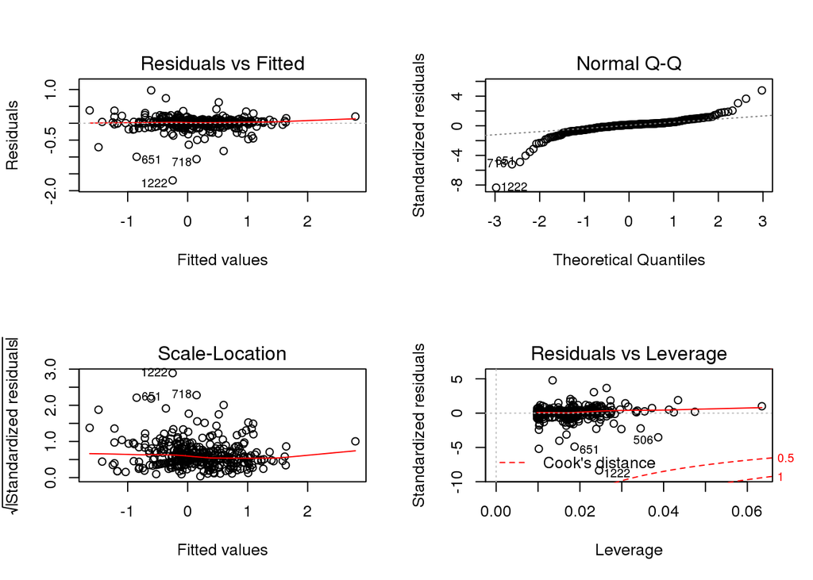

```r
par(mfrow=c(2,2))
plot(mod)
```

```r
par(mfrow=c(1,1))

mod <- lm(lnheightoct14 ~ lnheightmay2014 + treatment*microsite , data=data)
summary(mod)
```

```
##
## Call:
## lm(formula = lnheightoct14 ~ lnheightmay2014 + treatment * microsite,
##     data = data)
##
## Residuals:
##      Min       1Q   Median       3Q      Max
## -1.62888 -0.05621  0.02311  0.06854  0.95954
##
## Coefficients:
##                        Estimate Std. Error t value Pr(>|t|)
## (Intercept)           -0.028278   0.034284  -0.825   0.4101
## lnheightmay2014        0.961308   0.020462  46.980   <2e-16 ***
## treatment1             0.001504   0.042137   0.036   0.9715
## treatment2            -0.037396   0.051109  -0.732   0.4649
## treatment3            -0.140562   0.053884  -2.609   0.0095 **
## microsite1             0.046398   0.047395   0.979   0.3283
## treatment1:microsite1 -0.069344   0.058695  -1.181   0.2383
## treatment2:microsite1 -0.040070   0.068753  -0.583   0.5604
## treatment3:microsite1  0.087601   0.074952   1.169   0.2433
## ---
## Signif. codes:  0 '***' 0.001 '**' 0.01 '*' 0.05 '.' 0.1 ' ' 1
##
## Residual standard error: 0.2049 on 332 degrees of freedom
##   (2 observations deleted due to missingness)
## Multiple R-squared:  0.8985, Adjusted R-squared:  0.8961
## F-statistic: 367.5 on 8 and 332 DF,  p-value: < 2.2e-16
```

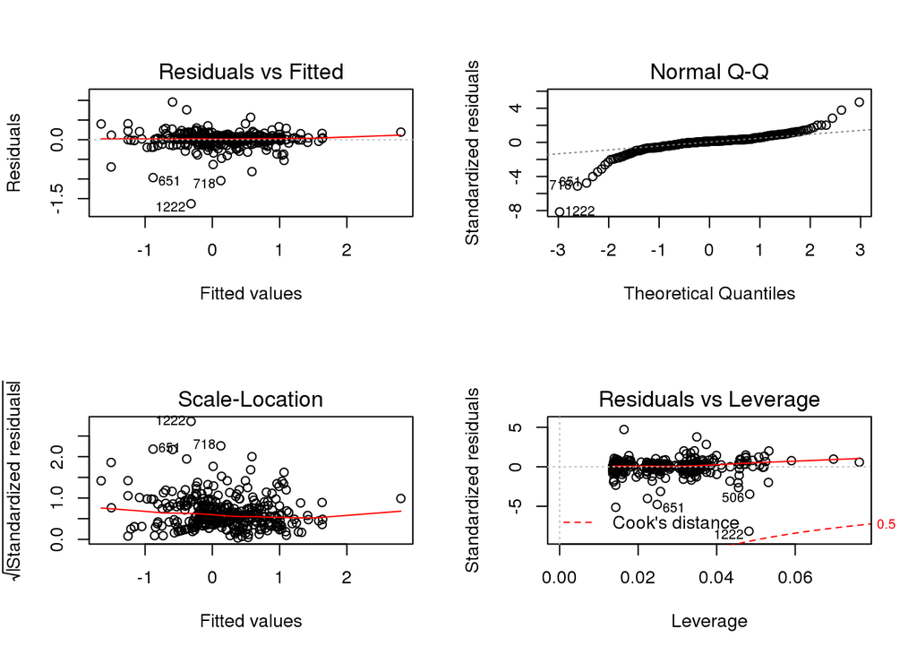

```r
par(mfrow=c(2,2))
plot(mod)
```

```r
par(mfrow=c(1,1))

mod <- lm(lnheightoct14 ~ lnheightmay2014, data=data)
mod2 <- lm(residuals(mod) ~ na.omit(data)$treatment*na.omit(data)$microsite)
summary(mod2)
```

```
##
## Call:
## lm(formula = residuals(mod) ~ na.omit(data)$treatment * na.omit(data)$microsite)
##
## Residuals:
##      Min       1Q   Median       3Q      Max
## -1.62548 -0.05818  0.02437  0.06751  0.96302
##
## Coefficients:
##                                                    Estimate Std. Error
## (Intercept)                                        0.012664   0.030498
## na.omit(data)$treatment1                           0.006749   0.038675
## na.omit(data)$treatment2                          -0.032106   0.048222
## na.omit(data)$treatment3                          -0.138052   0.053223
## na.omit(data)$microsite1                           0.046859   0.047309
## na.omit(data)$treatment1:na.omit(data)$microsite1 -0.071191   0.058324
## na.omit(data)$treatment2:na.omit(data)$microsite1 -0.040943   0.068604
## na.omit(data)$treatment3:na.omit(data)$microsite1  0.088965   0.074726
##                                                   t value Pr(>|t|)
## (Intercept)                                         0.415  0.67824
## na.omit(data)$treatment1                            0.174  0.86158
## na.omit(data)$treatment2                           -0.666  0.50600
## na.omit(data)$treatment3                           -2.594  0.00991 **
## na.omit(data)$microsite1                            0.990  0.32266
## na.omit(data)$treatment1:na.omit(data)$microsite1  -1.221  0.22310
## na.omit(data)$treatment2:na.omit(data)$microsite1  -0.597  0.55105
## na.omit(data)$treatment3:na.omit(data)$microsite1   1.191  0.23468
## ---
## Signif. codes:  0 '***' 0.001 '**' 0.01 '*' 0.05 '.' 0.1 ' ' 1
##
## Residual standard error: 0.2046 on 333 degrees of freedom
## Multiple R-squared:  0.03581,    Adjusted R-squared:  0.01554
## F-statistic: 1.767 on 7 and 333 DF,  p-value: 0.09309
```

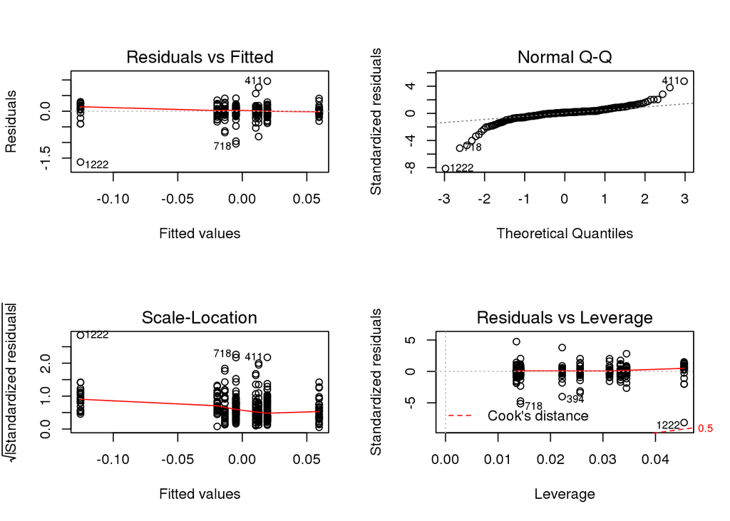

```r
par(mfrow=c(2,2))
plot(mod2)
```

```r
par(mfrow=c(1,1))
```

1. The height of the saplings was not very high at the beginning of the experiment.
2. I didn’t take in account terrace effect as random factor (Altough we do not except a such big change in the result).

Let’s check that!

### Saplings height distribution

We have to untransform data. We did it before (`data$may` and `data$oct`)

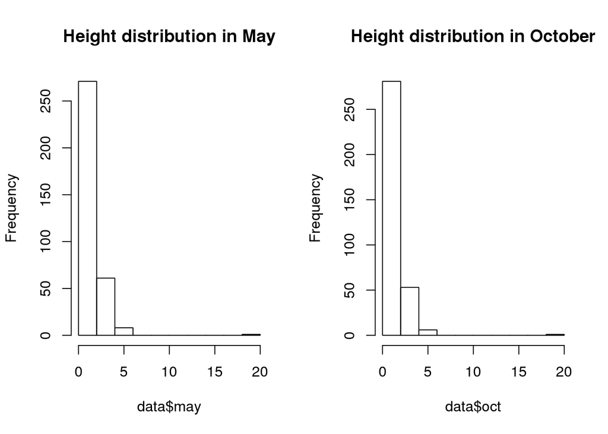

```r
par(mfrow=c(1,2))
summary(data$may)
summary(data$oct)
hist(data$may, main ="Height distribution in May")
hist(data$oct, main ="Height distribution in October")
```

```r
par(mfrow=c(1,1))
```

[output not shown]

### Calculation of the proportion of height loss during the summer

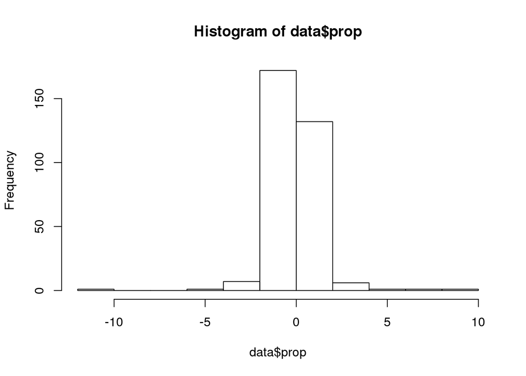

```r
data$prop <- (data$lnheightmay2014 - data$lnheightoct14)/data$lnheightmay2014
hist(data$prop)
```

```r
summary(data$prop)
```

```
##    Min. 1st Qu.  Median    Mean 3rd Qu.    Max.    NA's
##    -Inf       0       0     NaN       0     Inf       5
```

It works not so well because of the ln transformation which produce a lot of infinite values when we calculated the proportion. Moreover, obviously, when we calculate a soustraction of logarithme, we divide the original data. Because $ln(x) - ln(y) = ln(\dfrac{x}{y})$. Let’s try with a tricky solution. We do not know the exact transformation Mart applied but we can calculate the proportion with data untransformed by exponential as we did before.

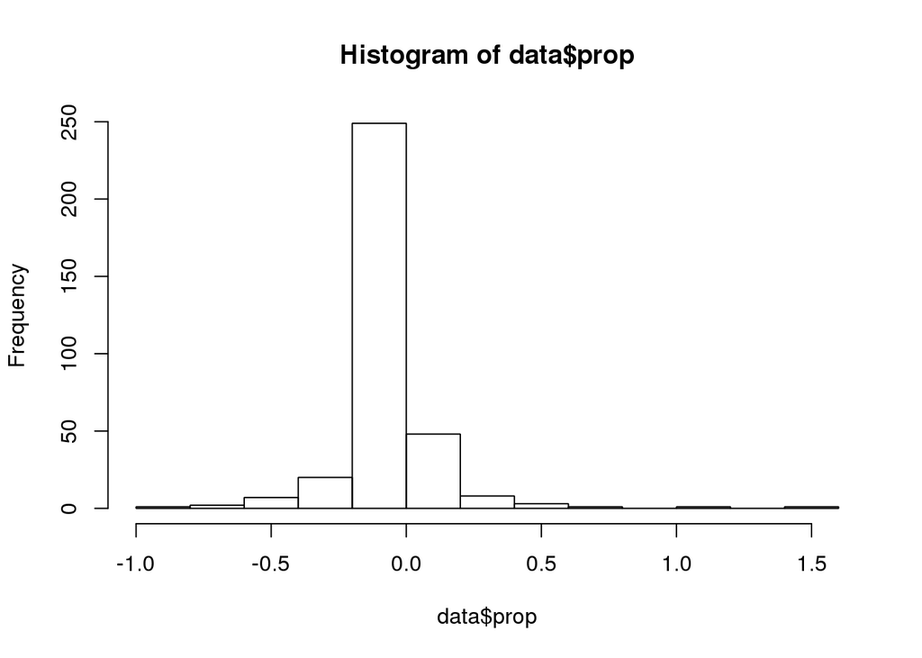

```r
data$prop <- (data$oct - data$may)/data$may
hist(data$prop)
```

```r
summary(data$prop)
```

```
##     Min.  1st Qu.   Median     Mean  3rd Qu.     Max.     NA's
## -0.83330 -0.09375  0.00000 -0.03303  0.00000  1.60000        2
```

## Statistical analysis

The effect of grazing and nursing is far to be great.

```r
mod <- lm(prop ~  treatment*microsite, data=data)
summary(mod)
```

```
##
## Call:
## lm(formula = prop ~ treatment * microsite, data = data)
##
## Residuals:
##      Min       1Q   Median       3Q      Max
## -0.71452 -0.06977  0.00897  0.04167  1.60897
##
## Coefficients:
##                       Estimate Std. Error t value Pr(>|t|)
## (Intercept)           -0.03839    0.02801  -1.371    0.171
## treatment1             0.02941    0.03551   0.828    0.408
## treatment2            -0.01013    0.04428  -0.229    0.819
## treatment3            -0.08043    0.04887  -1.646    0.101
## microsite1             0.03929    0.04344   0.904    0.366
## treatment1:microsite1 -0.06737    0.05356  -1.258    0.209
## treatment2:microsite1 -0.03245    0.06300  -0.515    0.607
## treatment3:microsite1  0.05838    0.06862   0.851    0.396
##
## Residual standard error: 0.1879 on 333 degrees of freedom
##   (2 observations deleted due to missingness)
## Multiple R-squared:  0.0215, Adjusted R-squared:  0.0009279
## F-statistic: 1.045 on 7 and 333 DF,  p-value: 0.3993
```

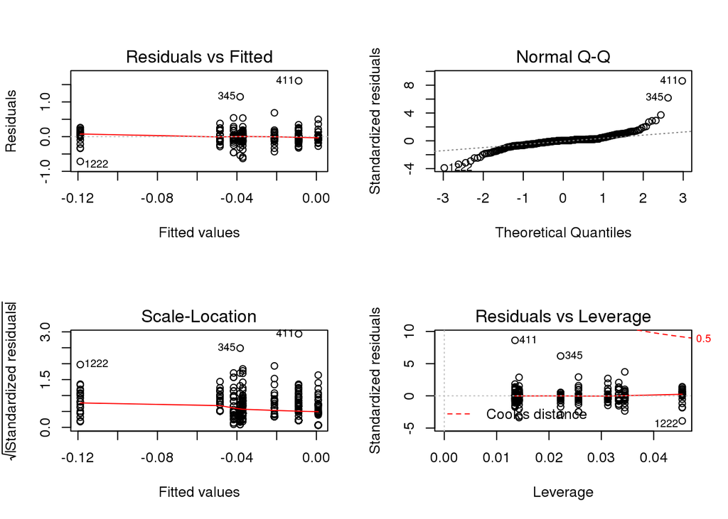

```r
par(mfrow=c(2,2))
plot(mod)
```

```r
par(mfrow=c(1,1))

mod <- lm(prop ~  treatment*microsite + terrace , data=data)
summary(mod)
```

```
##
## Call:
## lm(formula = prop ~ treatment * microsite + terrace, data = data)
##
## Residuals:
##      Min       1Q   Median       3Q      Max
## -0.68976 -0.06515  0.00364  0.04210  1.60364
##
## Coefficients:
##                       Estimate Std. Error t value Pr(>|t|)
## (Intercept)           -0.02122    0.03225  -0.658   0.5109
## treatment1             0.01758    0.03608   0.487   0.6264
## treatment2            -0.02169    0.04470  -0.485   0.6279
## treatment3            -0.09114    0.04979  -1.830   0.0681 .
## microsite1             0.03139    0.04367   0.719   0.4727
## terrace3               0.01406    0.02652   0.530   0.5962
## terrace4              -0.03121    0.02427  -1.286   0.1994
## treatment1:microsite1 -0.06090    0.05362  -1.136   0.2568
## treatment2:microsite1 -0.02640    0.06299  -0.419   0.6754
## treatment3:microsite1  0.07021    0.06885   1.020   0.3086
## ---
## Signif. codes:  0 '***' 0.001 '**' 0.01 '*' 0.05 '.' 0.1 ' ' 1
##
## Residual standard error: 0.1876 on 331 degrees of freedom
##   (2 observations deleted due to missingness)
## Multiple R-squared:  0.03064,    Adjusted R-squared:  0.00428
## F-statistic: 1.162 on 9 and 331 DF,  p-value: 0.3185
```

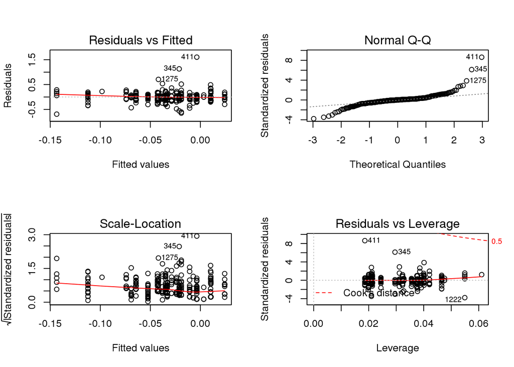

```r
par(mfrow=c(2,2))
plot(mod)
```

```r
par(mfrow=c(1,1))
```

Let’s try with lme by putting the terraces as random factor.

```r
library(lme4)
mod <- lm(prop ~ treatment + microsite, data)

mod1 <- lm(prop ~ treatment*microsite, data)
AIC(mod,mod1)
```

```
##      df       AIC
## mod   6 -163.9585
## mod1  9 -162.6823
```

```r
mod2 <- lm(prop ~ treatment*microsite + terrace, data)
AIC(mod2,mod1)
```

```
##      df       AIC
## mod2 11 -161.8827
## mod1  9 -162.6823
```

The interaction between treatment and microsite do not improve the model. The same for terrace effect. Now let’s try with terrace as random effect. I put the random effect as `1|terrace` which means that in the different terraces, we can have different intercept for the relationships due to environmental variation. I didn’t put in the slope because there is, on my opinon, no reason to think the effect of grazer (variable: `treatment`) can be different between the terrace. Idem for patch effect.

```r
mod <- lmer(prop ~ treatment + (1|terrace), data, REML=FALSE)
summary(mod)
```

```
## Linear mixed model fit by maximum likelihood  ['lmerMod']
## Formula: prop ~ treatment + (1 | terrace)
##    Data: data
##
##      AIC      BIC   logLik deviance df.resid
##   -163.6   -140.6     87.8   -175.6      335
##
## Scaled residuals:
##     Min      1Q  Median      3Q     Max
## -4.1169 -0.3651  0.1179  0.2387  8.6748
##
## Random effects:
##  Groups   Name        Variance  Std.Dev.
##  terrace  (Intercept) 1.400e-15 3.741e-08
##  Residual             3.499e-02 1.871e-01
## Number of obs: 341, groups:  terrace, 3
##
## Fixed effects:
##               Estimate Std. Error t value
## (Intercept) -0.0220562  0.0213163  -1.035
## treatment1  -0.0005656  0.0264075  -0.021
## treatment2  -0.0225939  0.0310073  -0.729
## treatment3  -0.0412173  0.0337701  -1.220
##
## Correlation of Fixed Effects:
##            (Intr) trtmn1 trtmn2
## treatment1 -0.807
## treatment2 -0.687  0.555
## treatment3 -0.631  0.510  0.434
```

```r
mod1 <- lmer(prop ~ treatment + microsite + (1|terrace), data, REML=FALSE)
AIC(mod,mod1)
```

```
##      df       AIC
## mod   6 -163.5746
## mod1  7 -161.9585
```

```r
summary(mod1)
```

```
## Linear mixed model fit by maximum likelihood  ['lmerMod']
## Formula: prop ~ treatment + microsite + (1 | terrace)
##    Data: data
##
##      AIC      BIC   logLik deviance df.resid
##   -162.0   -135.1     88.0   -176.0      334
##
## Scaled residuals:
##     Min      1Q  Median      3Q     Max
## -4.0808 -0.3324  0.0863  0.2095  8.7125
##
## Random effects:
##  Groups   Name        Variance  Std.Dev.
##  terrace  (Intercept) 1.145e-16 1.070e-08
##  Residual             3.495e-02 1.869e-01
## Number of obs: 341, groups:  terrace, 3
##
## Fixed effects:
##              Estimate Std. Error t value
## (Intercept) -0.027305   0.022926  -1.191
## treatment1  -0.001456   0.026432  -0.055
## treatment2  -0.024484   0.031140  -0.786
## treatment3  -0.043150   0.033895  -1.273
## microsite1   0.012631   0.020380   0.620
##
## Correlation of Fixed Effects:
##            (Intr) trtmn1 trtmn2 trtmn3
## treatment1 -0.729
## treatment2 -0.600  0.557
## treatment3 -0.550  0.512  0.439
## microsite1 -0.369 -0.054 -0.098 -0.092
```

```r
mod2 <- lmer(prop ~ treatment * microsite + (1|terrace), data, REML=FALSE)
AIC(mod,mod2)
```

```
##      df       AIC
## mod   6 -163.5746
## mod2 10 -160.6823
```

```r
summary(mod2)
```

```
## Linear mixed model fit by maximum likelihood  ['lmerMod']
## Formula: prop ~ treatment * microsite + (1 | terrace)
##    Data: data
##
##      AIC      BIC   logLik deviance df.resid
##   -160.7   -122.4     90.3   -180.7      331
##
## Scaled residuals:
##     Min      1Q  Median      3Q     Max
## -3.8487 -0.3758  0.0483  0.2245  8.6665
##
## Random effects:
##  Groups   Name        Variance Std.Dev.
##  terrace  (Intercept) 0.00000  0.0000
##  Residual             0.03447  0.1857
## Number of obs: 341, groups:  terrace, 3
##
## Fixed effects:
##                       Estimate Std. Error t value
## (Intercept)           -0.03839    0.02768  -1.387
## treatment1             0.02941    0.03510   0.838
## treatment2            -0.01013    0.04376  -0.232
## treatment3            -0.08043    0.04830  -1.665
## microsite1             0.03929    0.04293   0.915
## treatment1:microsite1 -0.06737    0.05293  -1.273
## treatment2:microsite1 -0.03245    0.06226  -0.521
## treatment3:microsite1  0.05838    0.06781   0.861
##
## Correlation of Fixed Effects:
##             (Intr) trtmn1 trtmn2 trtmn3 mcrst1 trt1:1 trt2:1
## treatment1  -0.789
## treatment2  -0.632  0.499
## treatment3  -0.573  0.452  0.362
## microsite1  -0.645  0.508  0.408  0.369
## trtmnt1:mc1  0.523 -0.663 -0.331 -0.300 -0.811
## trtmnt2:mc1  0.445 -0.351 -0.703 -0.255 -0.690  0.559
## trtmnt3:mc1  0.408 -0.322 -0.258 -0.712 -0.633  0.514  0.437
```

```r
mod3 <- lm(prop ~ treatment * microsite , data)
summary(mod3)
```

```
##
## Call:
## lm(formula = prop ~ treatment * microsite, data = data)
##
## Residuals:
##      Min       1Q   Median       3Q      Max
## -0.71452 -0.06977  0.00897  0.04167  1.60897
##
## Coefficients:
##                       Estimate Std. Error t value Pr(>|t|)
## (Intercept)           -0.03839    0.02801  -1.371    0.171
## treatment1             0.02941    0.03551   0.828    0.408
## treatment2            -0.01013    0.04428  -0.229    0.819
## treatment3            -0.08043    0.04887  -1.646    0.101
## microsite1             0.03929    0.04344   0.904    0.366
## treatment1:microsite1 -0.06737    0.05356  -1.258    0.209
## treatment2:microsite1 -0.03245    0.06300  -0.515    0.607
## treatment3:microsite1  0.05838    0.06862   0.851    0.396
##
## Residual standard error: 0.1879 on 333 degrees of freedom
##   (2 observations deleted due to missingness)
## Multiple R-squared:  0.0215, Adjusted R-squared:  0.0009279
## F-statistic: 1.045 on 7 and 333 DF,  p-value: 0.3993
```

## Conclusion

Overall, the effects are weak and none of the estimated parameters are significantly different from 0. Moreover, the confidence interval of most of the estimated parameters falls in 0. Obsviously, it will take more time and may be more data of the parameter estimation. One big biais for example, I didn’t take in account the fact that the groups are unbalanced which play a role in variance calculation and so, parameters estimation.